# Risk Factor Analysis

## Outcome Variable

**Outcome Variable:** whz

## Predictor Variables

**Intervention Variable:** safeh20

**Adjustment Set:**

unadjusted

## Stratifying Variables

The analysis was stratified on these variable(s):

- agecat
- studyid
- country

## Data Summary

| agecat | studyid | country | safeh20 | n_cell | n |
| --- | --- | --- | --- | --- | --- |
| Birth | MAL-ED | BANGLADESH | 1 | 0 | 201 |
| Birth | MAL-ED | BANGLADESH | 0 | 201 | 201 |
| Birth | MAL-ED | BRAZIL | 1 | 0 | 38 |
| Birth | MAL-ED | BRAZIL | 0 | 38 | 38 |
| Birth | MAL-ED | INDIA | 1 | 0 | 39 |
| Birth | MAL-ED | INDIA | 0 | 39 | 39 |
| Birth | MAL-ED | NEPAL | 1 | 1 | 25 |
| Birth | MAL-ED | NEPAL | 0 | 24 | 25 |
| Birth | MAL-ED | PERU | 1 | 9 | 202 |
| Birth | MAL-ED | PERU | 0 | 193 | 202 |
| Birth | MAL-ED | SOUTH AFRICA | 1 | 13 | 95 |
| Birth | MAL-ED | SOUTH AFRICA | 0 | 82 | 95 |
| Birth | MAL-ED | TANZANIA, UNITED REPUBLIC OF | 1 | 74 | 111 |
| Birth | MAL-ED | TANZANIA, UNITED REPUBLIC OF | 0 | 37 | 111 |
| Birth | NIH-Birth | BANGLADESH | 1 | 573 | 575 |
| Birth | NIH-Birth | BANGLADESH | 0 | 2 | 575 |
| Birth | NIH-Crypto | BANGLADESH | 1 | 707 | 707 |
| Birth | NIH-Crypto | BANGLADESH | 0 | 0 | 707 |
| Birth | PROVIDE | BANGLADESH | 1 | 45 | 45 |
| Birth | PROVIDE | BANGLADESH | 0 | 0 | 45 |
| 6 months | CONTENT | PERU | 1 | 54 | 57 |
| 6 months | CONTENT | PERU | 0 | 3 | 57 |
| 6 months | LCNI-5 | MALAWI | 1 | 672 | 816 |
| 6 months | LCNI-5 | MALAWI | 0 | 144 | 816 |
| 6 months | MAL-ED | BANGLADESH | 1 | 0 | 240 |
| 6 months | MAL-ED | BANGLADESH | 0 | 240 | 240 |
| 6 months | MAL-ED | BRAZIL | 1 | 0 | 142 |
| 6 months | MAL-ED | BRAZIL | 0 | 142 | 142 |
| 6 months | MAL-ED | INDIA | 1 | 0 | 235 |
| 6 months | MAL-ED | INDIA | 0 | 235 | 235 |
| 6 months | MAL-ED | NEPAL | 1 | 1 | 233 |
| 6 months | MAL-ED | NEPAL | 0 | 232 | 233 |
| 6 months | MAL-ED | PERU | 1 | 11 | 259 |
| 6 months | MAL-ED | PERU | 0 | 248 | 259 |
| 6 months | MAL-ED | SOUTH AFRICA | 1 | 37 | 248 |
| 6 months | MAL-ED | SOUTH AFRICA | 0 | 211 | 248 |
| 6 months | MAL-ED | TANZANIA, UNITED REPUBLIC OF | 1 | 168 | 246 |
| 6 months | MAL-ED | TANZANIA, UNITED REPUBLIC OF | 0 | 78 | 246 |
| 6 months | NIH-Birth | BANGLADESH | 1 | 535 | 537 |
| 6 months | NIH-Birth | BANGLADESH | 0 | 2 | 537 |
| 6 months | NIH-Crypto | BANGLADESH | 1 | 715 | 715 |
| 6 months | NIH-Crypto | BANGLADESH | 0 | 0 | 715 |
| 6 months | PROVIDE | BANGLADESH | 1 | 11 | 11 |
| 6 months | PROVIDE | BANGLADESH | 0 | 0 | 11 |
| 6 months | SAS-FoodSuppl | INDIA | 1 | 380 | 380 |
| 6 months | SAS-FoodSuppl | INDIA | 0 | 0 | 380 |
| 24 months | CONTENT | PERU | 1 | 45 | 48 |
| 24 months | CONTENT | PERU | 0 | 3 | 48 |
| 24 months | LCNI-5 | MALAWI | 1 | 464 | 558 |
| 24 months | LCNI-5 | MALAWI | 0 | 94 | 558 |
| 24 months | MAL-ED | BANGLADESH | 1 | 0 | 212 |
| 24 months | MAL-ED | BANGLADESH | 0 | 212 | 212 |
| 24 months | MAL-ED | BRAZIL | 1 | 0 | 113 |
| 24 months | MAL-ED | BRAZIL | 0 | 113 | 113 |
| 24 months | MAL-ED | INDIA | 1 | 0 | 227 |
| 24 months | MAL-ED | INDIA | 0 | 227 | 227 |
| 24 months | MAL-ED | NEPAL | 1 | 1 | 226 |
| 24 months | MAL-ED | NEPAL | 0 | 225 | 226 |
| 24 months | MAL-ED | PERU | 1 | 7 | 193 |
| 24 months | MAL-ED | PERU | 0 | 186 | 193 |
| 24 months | MAL-ED | SOUTH AFRICA | 1 | 34 | 237 |
| 24 months | MAL-ED | SOUTH AFRICA | 0 | 203 | 237 |
| 24 months | MAL-ED | TANZANIA, UNITED REPUBLIC OF | 1 | 145 | 213 |
| 24 months | MAL-ED | TANZANIA, UNITED REPUBLIC OF | 0 | 68 | 213 |
| 24 months | NIH-Birth | BANGLADESH | 1 | 426 | 428 |
| 24 months | NIH-Birth | BANGLADESH | 0 | 2 | 428 |
| 24 months | NIH-Crypto | BANGLADESH | 1 | 514 | 514 |
| 24 months | NIH-Crypto | BANGLADESH | 0 | 0 | 514 |
| 24 months | PROVIDE | BANGLADESH | 1 | 9 | 9 |
| 24 months | PROVIDE | BANGLADESH | 0 | 0 | 9 |

The following strata were considered:

- agecat: 24 months, studyid: CONTENT, country: PERU
- agecat: 24 months, studyid: LCNI-5, country: MALAWI
- agecat: 24 months, studyid: MAL-ED, country: BANGLADESH
- agecat: 24 months, studyid: MAL-ED, country: BRAZIL
- agecat: 24 months, studyid: MAL-ED, country: INDIA
- agecat: 24 months, studyid: MAL-ED, country: NEPAL
- agecat: 24 months, studyid: MAL-ED, country: PERU
- agecat: 24 months, studyid: MAL-ED, country: SOUTH AFRICA
- agecat: 24 months, studyid: MAL-ED, country: TANZANIA, UNITED REPUBLIC OF
- agecat: 24 months, studyid: NIH-Birth, country: BANGLADESH
- agecat: 24 months, studyid: NIH-Crypto, country: BANGLADESH
- agecat: 24 months, studyid: PROVIDE, country: BANGLADESH
- agecat: 6 months, studyid: CONTENT, country: PERU
- agecat: 6 months, studyid: LCNI-5, country: MALAWI
- agecat: 6 months, studyid: MAL-ED, country: BANGLADESH
- agecat: 6 months, studyid: MAL-ED, country: BRAZIL
- agecat: 6 months, studyid: MAL-ED, country: INDIA
- agecat: 6 months, studyid: MAL-ED, country: NEPAL
- agecat: 6 months, studyid: MAL-ED, country: PERU
- agecat: 6 months, studyid: MAL-ED, country: SOUTH AFRICA
- agecat: 6 months, studyid: MAL-ED, country: TANZANIA, UNITED REPUBLIC OF
- agecat: 6 months, studyid: NIH-Birth, country: BANGLADESH
- agecat: 6 months, studyid: NIH-Crypto, country: BANGLADESH
- agecat: 6 months, studyid: PROVIDE, country: BANGLADESH
- agecat: 6 months, studyid: SAS-FoodSuppl, country: INDIA
- agecat: Birth, studyid: MAL-ED, country: BANGLADESH
- agecat: Birth, studyid: MAL-ED, country: BRAZIL
- agecat: Birth, studyid: MAL-ED, country: INDIA
- agecat: Birth, studyid: MAL-ED, country: NEPAL
- agecat: Birth, studyid: MAL-ED, country: PERU
- agecat: Birth, studyid: MAL-ED, country: SOUTH AFRICA
- agecat: Birth, studyid: MAL-ED, country: TANZANIA, UNITED REPUBLIC OF
- agecat: Birth, studyid: NIH-Birth, country: BANGLADESH
- agecat: Birth, studyid: NIH-Crypto, country: BANGLADESH
- agecat: Birth, studyid: PROVIDE, country: BANGLADESH

### Dropped Strata

- agecat: Birth, studyid: MAL-ED, country: BANGLADESH
- agecat: Birth, studyid: MAL-ED, country: BRAZIL
- agecat: Birth, studyid: MAL-ED, country: INDIA
- agecat: Birth, studyid: MAL-ED, country: NEPAL
- agecat: Birth, studyid: NIH-Birth, country: BANGLADESH
- agecat: Birth, studyid: NIH-Crypto, country: BANGLADESH
- agecat: Birth, studyid: PROVIDE, country: BANGLADESH
- agecat: 6 months, studyid: CONTENT, country: PERU
- agecat: 6 months, studyid: MAL-ED, country: BANGLADESH
- agecat: 6 months, studyid: MAL-ED, country: BRAZIL
- agecat: 6 months, studyid: MAL-ED, country: INDIA
- agecat: 6 months, studyid: MAL-ED, country: NEPAL
- agecat: 6 months, studyid: NIH-Birth, country: BANGLADESH
- agecat: 6 months, studyid: NIH-Crypto, country: BANGLADESH
- agecat: 6 months, studyid: PROVIDE, country: BANGLADESH
- agecat: 6 months, studyid: SAS-FoodSuppl, country: INDIA
- agecat: 24 months, studyid: CONTENT, country: PERU
- agecat: 24 months, studyid: MAL-ED, country: BANGLADESH
- agecat: 24 months, studyid: MAL-ED, country: BRAZIL
- agecat: 24 months, studyid: MAL-ED, country: INDIA
- agecat: 24 months, studyid: MAL-ED, country: NEPAL
- agecat: 24 months, studyid: NIH-Birth, country: BANGLADESH
- agecat: 24 months, studyid: NIH-Crypto, country: BANGLADESH
- agecat: 24 months, studyid: PROVIDE, country: BANGLADESH

## Methods Detail

We’re interested in the causal parameters $E[Y_a]$ for all values of $a \in \mathcal{A}$. These parameters represent the mean outcome if, possibly contrary to fact, we intervened to set all units to have $A=a$. Under the randomization and positivity assumptions, these are identified by the statistical parameters $\psi_a=E_W[E_{Y|A,W}(Y|A=a,W)]$. In addition, we’re interested in the mean of $Y$, $E[Y]$ under no intervention (the observed mean). We will estimate these parameters by using SuperLearner to fit the relevant likelihood factors – $E_{Y|A,W}(Y|A=a,W)$ and $p(A=a|W)$, and then updating our likelihood fit using a joint TMLE.

For unadjusted analyses ($W=\{\}$), initial likelihoods were estimated using Lrnr_glm to estimate the simple $E(Y|A)$ and Lrnr_mean to estimate $p(A)$. For adjusted analyses, a small library containing Lrnr_glmnet, Lrnr_xgboost, and Lrnr_mean was used.

Having estimated these parameters, we will then use the delta method to estimate relative risks and attributable risks relative to a prespecified baseline level of $A$.

# Results Detail

## Results Plots

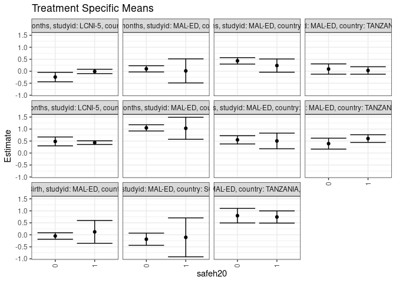

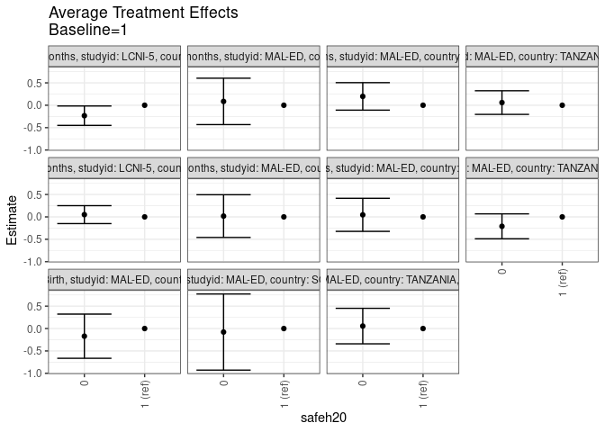

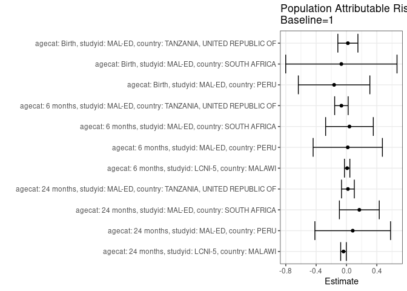

## Results Table

### Parameter: TSM

| agecat | studyid | country | intervention_level | baseline_level | estimate | ci_lower | ci_upper |
| --- | --- | --- | --- | --- | --- | --- | --- |
| Birth | MAL-ED | PERU | 1 | NA | 0.1222222 | -0.3522777 | 0.5967221 |
| Birth | MAL-ED | PERU | 0 | NA | -0.0486528 | -0.1831806 | 0.0858749 |
| Birth | MAL-ED | SOUTH AFRICA | 1 | NA | -0.1053846 | -0.9165393 | 0.7057701 |
| Birth | MAL-ED | SOUTH AFRICA | 0 | NA | -0.1836585 | -0.4374958 | 0.0701788 |
| Birth | MAL-ED | TANZANIA, UNITED REPUBLIC OF | 1 | NA | 0.7435135 | 0.4886098 | 0.9984172 |
| Birth | MAL-ED | TANZANIA, UNITED REPUBLIC OF | 0 | NA | 0.7986486 | 0.4948919 | 1.1024054 |
| 6 months | LCNI-5 | MALAWI | 1 | NA | 0.4328274 | 0.3555921 | 0.5100626 |
| 6 months | LCNI-5 | MALAWI | 0 | NA | 0.4834722 | 0.2986770 | 0.6682674 |
| 6 months | MAL-ED | PERU | 1 | NA | 1.0318182 | 0.5730192 | 1.4906171 |
| 6 months | MAL-ED | PERU | 0 | NA | 1.0494556 | 0.9193408 | 1.1795705 |
| 6 months | MAL-ED | SOUTH AFRICA | 1 | NA | 0.5036937 | 0.1768323 | 0.8305551 |
| 6 months | MAL-ED | SOUTH AFRICA | 0 | NA | 0.5499131 | 0.3779029 | 0.7219233 |
| 6 months | MAL-ED | TANZANIA, UNITED REPUBLIC OF | 1 | NA | 0.6025496 | 0.4419945 | 0.7631047 |
| 6 months | MAL-ED | TANZANIA, UNITED REPUBLIC OF | 0 | NA | 0.3920299 | 0.1645583 | 0.6195015 |
| 24 months | LCNI-5 | MALAWI | 1 | NA | -0.0084698 | -0.0986734 | 0.0817338 |
| 24 months | LCNI-5 | MALAWI | 0 | NA | -0.2418617 | -0.4385933 | -0.0451301 |
| 24 months | MAL-ED | PERU | 1 | NA | 0.0150000 | -0.4862499 | 0.5162499 |
| 24 months | MAL-ED | PERU | 0 | NA | 0.1005332 | -0.0288801 | 0.2299464 |
| 24 months | MAL-ED | SOUTH AFRICA | 1 | NA | 0.2360294 | -0.0398483 | 0.5119071 |
| 24 months | MAL-ED | SOUTH AFRICA | 0 | NA | 0.4338136 | 0.3002318 | 0.5673954 |
| 24 months | MAL-ED | TANZANIA, UNITED REPUBLIC OF | 1 | NA | 0.0327011 | -0.1221726 | 0.1875749 |
| 24 months | MAL-ED | TANZANIA, UNITED REPUBLIC OF | 0 | NA | 0.0925735 | -0.1208495 | 0.3059966 |

### Parameter: E(Y)

| agecat | studyid | country | intervention_level | baseline_level | estimate | ci_lower | ci_upper |
| --- | --- | --- | --- | --- | --- | --- | --- |
| Birth | MAL-ED | PERU | NA | NA | -0.0410396 | -0.1713918 | 0.0893125 |
| Birth | MAL-ED | SOUTH AFRICA | NA | NA | -0.1729474 | -0.4186222 | 0.0727275 |
| Birth | MAL-ED | TANZANIA, UNITED REPUBLIC OF | NA | NA | 0.7618919 | 0.5640188 | 0.9597650 |
| 6 months | LCNI-5 | MALAWI | NA | NA | 0.4417647 | 0.3702742 | 0.5132552 |
| 6 months | MAL-ED | PERU | NA | NA | 1.0487066 | 0.9226025 | 1.1748107 |
| 6 months | MAL-ED | SOUTH AFRICA | NA | NA | 0.5430175 | 0.3887455 | 0.6972895 |
| 6 months | MAL-ED | TANZANIA, UNITED REPUBLIC OF | NA | NA | 0.5357995 | 0.4039850 | 0.6676139 |
| 24 months | LCNI-5 | MALAWI | NA | NA | -0.0477867 | -0.1301103 | 0.0345368 |
| 24 months | MAL-ED | PERU | NA | NA | 0.0974309 | -0.0286270 | 0.2234888 |
| 24 months | MAL-ED | SOUTH AFRICA | NA | NA | 0.4054395 | 0.2840471 | 0.5268320 |
| 24 months | MAL-ED | TANZANIA, UNITED REPUBLIC OF | NA | NA | 0.0518153 | -0.0737716 | 0.1774023 |

### Parameter: ATE

| agecat | studyid | country | intervention_level | baseline_level | estimate | ci_lower | ci_upper |
| --- | --- | --- | --- | --- | --- | --- | --- |
| Birth | MAL-ED | PERU | 1 | 1 | 0.0000000 | 0.0000000 | 0.0000000 |
| Birth | MAL-ED | PERU | 0 | 1 | -0.1708751 | -0.6640768 | 0.3223266 |
| Birth | MAL-ED | SOUTH AFRICA | 1 | 1 | 0.0000000 | 0.0000000 | 0.0000000 |
| Birth | MAL-ED | SOUTH AFRICA | 0 | 1 | -0.0782739 | -0.9282183 | 0.7716704 |
| Birth | MAL-ED | TANZANIA, UNITED REPUBLIC OF | 1 | 1 | 0.0000000 | 0.0000000 | 0.0000000 |
| Birth | MAL-ED | TANZANIA, UNITED REPUBLIC OF | 0 | 1 | 0.0551351 | -0.3414050 | 0.4516752 |
| 6 months | LCNI-5 | MALAWI | 1 | 1 | 0.0000000 | 0.0000000 | 0.0000000 |
| 6 months | LCNI-5 | MALAWI | 0 | 1 | 0.0506448 | -0.1496413 | 0.2509310 |
| 6 months | MAL-ED | PERU | 1 | 1 | 0.0000000 | 0.0000000 | 0.0000000 |
| 6 months | MAL-ED | PERU | 0 | 1 | 0.0176375 | -0.4592550 | 0.4945299 |
| 6 months | MAL-ED | SOUTH AFRICA | 1 | 1 | 0.0000000 | 0.0000000 | 0.0000000 |
| 6 months | MAL-ED | SOUTH AFRICA | 0 | 1 | 0.0462194 | -0.3231393 | 0.4155781 |
| 6 months | MAL-ED | TANZANIA, UNITED REPUBLIC OF | 1 | 1 | 0.0000000 | 0.0000000 | 0.0000000 |
| 6 months | MAL-ED | TANZANIA, UNITED REPUBLIC OF | 0 | 1 | -0.2105197 | -0.4889461 | 0.0679067 |
| 24 months | LCNI-5 | MALAWI | 1 | 1 | 0.0000000 | 0.0000000 | 0.0000000 |
| 24 months | LCNI-5 | MALAWI | 0 | 1 | -0.2333919 | -0.4498174 | -0.0169663 |
| 24 months | MAL-ED | PERU | 1 | 1 | 0.0000000 | 0.0000000 | 0.0000000 |
| 24 months | MAL-ED | PERU | 0 | 1 | 0.0855332 | -0.4321533 | 0.6032196 |
| 24 months | MAL-ED | SOUTH AFRICA | 1 | 1 | 0.0000000 | 0.0000000 | 0.0000000 |
| 24 months | MAL-ED | SOUTH AFRICA | 0 | 1 | 0.1977842 | -0.1087327 | 0.5043011 |
| 24 months | MAL-ED | TANZANIA, UNITED REPUBLIC OF | 1 | 1 | 0.0000000 | 0.0000000 | 0.0000000 |
| 24 months | MAL-ED | TANZANIA, UNITED REPUBLIC OF | 0 | 1 | 0.0598724 | -0.2038230 | 0.3235678 |

### Parameter: PAR

| agecat | studyid | country | intervention_level | baseline_level | estimate | ci_lower | ci_upper |
| --- | --- | --- | --- | --- | --- | --- | --- |
| Birth | MAL-ED | PERU | 1 | NA | -0.1632618 | -0.6345144 | 0.3079907 |
| Birth | MAL-ED | SOUTH AFRICA | 1 | NA | -0.0675628 | -0.8012191 | 0.6660936 |
| Birth | MAL-ED | TANZANIA, UNITED REPUBLIC OF | 1 | NA | 0.0183784 | -0.1138909 | 0.1506476 |
| 6 months | LCNI-5 | MALAWI | 1 | NA | 0.0089373 | -0.0264321 | 0.0443068 |
| 6 months | MAL-ED | PERU | 1 | NA | 0.0168884 | -0.4397501 | 0.4735269 |
| 6 months | MAL-ED | SOUTH AFRICA | 1 | NA | 0.0393238 | -0.2749357 | 0.3535833 |
| 6 months | MAL-ED | TANZANIA, UNITED REPUBLIC OF | 1 | NA | -0.0667501 | -0.1558798 | 0.0223795 |
| 24 months | LCNI-5 | MALAWI | 1 | NA | -0.0393169 | -0.0764904 | -0.0021434 |
| 24 months | MAL-ED | PERU | 1 | NA | 0.0824309 | -0.4164844 | 0.5813463 |
| 24 months | MAL-ED | SOUTH AFRICA | 1 | NA | 0.1694101 | -0.0932828 | 0.4321031 |
| 24 months | MAL-ED | TANZANIA, UNITED REPUBLIC OF | 1 | NA | 0.0191142 | -0.0651541 | 0.1033824 |